# Estudi exploratori - homes

Eudald Correig

19/6/2020

Traiem les resines i l’omacor perquè tenen massa poca variabilitat.

# Anàlisi univariant

Fem un test de chi^2 per entre prendre estatines o no i morir de covid o no:

```
##
##
##    Cell Contents
## |-------------------------|
## |                       N |
## | Chi-square contribution |
## |           N / Row Total |
## |           N / Col Total |
## |         N / Table Total |
## |-------------------------|
##
##
## Total Observations in Table:  870.2011
##
##
##              |               No |               Sí |        Row Total |
## -------------|------------------|------------------|------------------|
##           No |              394 |              116 |              511 |
##              |            0.023 |            0.081 |                  |
##              |            0.771 |            0.229 |            0.587 |
##              |            0.583 |            0.603 |                  |
##              |            0.453 |            0.134 |                  |
## -------------|------------------|------------------|------------------|
##           Sí |              282 |               77 |              359 |
##              |            0.033 |            0.115 |                  |
##              |            0.786 |            0.214 |            0.413 |
##              |            0.417 |            0.397 |                  |
##              |            0.324 |            0.088 |                  |
## -------------|------------------|------------------|------------------|
## Column Total |              676 |              193 |              870 |
##              |            0.777 |            0.223 |                  |
## -------------|------------------|------------------|------------------|
##
##
## Statistics for All Table Factors
##
##
## Pearson's Chi-squared test
## ------------------------------------------------------------
## Chi^2 =  0.2511258     d.f. =  1     p =  0.6162835
##
## Pearson's Chi-squared test with Yates' continuity correction
## ------------------------------------------------------------
## Chi^2 =  0.1750596     d.f. =  1     p =  0.6756538
##
##
```

Fem un gràfic:

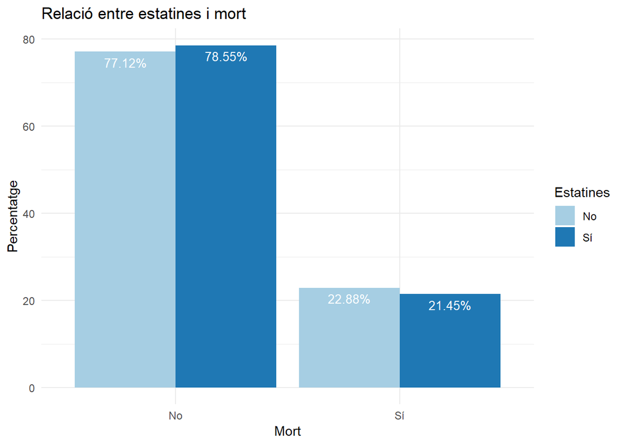

# Models

Comencem amb una regrssió logística “normal”, primer només amb estatines i després amb totes les variables:

## Només estatines

```
##
## Call:
## glm(formula = Mort ~ Estatines, family = "binomial", data = df[,
##     c(1:43, 59, 60)], weights = weights)
##
## Deviance Residuals:
##     Min       1Q   Median       3Q      Max
## -4.0283  -0.6949  -0.1862  -0.0442   5.1413
##
## Coefficients:
##             Estimate Std. Error z value Pr(>|z|)
## (Intercept) -1.21483    0.10528 -11.539   <2e-16 ***
## EstatinesSí -0.08327    0.16619  -0.501    0.616
## ---
## Signif. codes:  0 '***' 0.001 '**' 0.01 '*' 0.05 '.' 0.1 ' ' 1
##
## (Dispersion parameter for binomial family taken to be 1)
##
##     Null deviance: 923.42  on 910  degrees of freedom
## Residual deviance: 923.17  on 909  degrees of freedom
## AIC: 911.85
##
## Number of Fisher Scoring iterations: 5
```

**Nota: a partir d’aquí ja tots els anàlisis són multivariants**.

Nota2: canvio el nom d’Antiagregants.Anticoagulants a A.A perquè si no ocupa massa i les coses es veuen malament.

```
##
## Call:
## glm(formula = Mort ~ . - weights, family = "binomial", data = df[,
##     c(1:43, 59, 60)], weights = weights)
##
## Deviance Residuals:
##     Min       1Q   Median       3Q      Max
## -3.2647  -0.2969  -0.0483  -0.0023   4.2396
##
## Coefficients:
##                                Estimate Std. Error z value Pr(>|z|)
## (Intercept)                  -7.987e-01  2.468e+00  -0.324 0.746204
## Edat                          9.869e-02  1.641e-02   6.015 1.79e-09 ***
## TabacNo                       2.428e-01  2.893e-01   0.839 0.401269
## TabacSí                      -1.598e-01  5.120e-01  -0.312 0.754918
## HTASí                         1.446e+00  4.188e-01   3.453 0.000555 ***
## HiperlipemiaSí                1.079e-01  4.607e-01   0.234 0.814853
## DiabetesSí                   -2.873e-01  4.133e-01  -0.695 0.486879
## ObesitatSí                   -6.521e-02  2.955e-01  -0.221 0.825345
## Ant.CISí                     -6.191e-01  3.521e-01  -1.758 0.078700 .
## Ant.IctusSí                  -3.108e-01  4.420e-01  -0.703 0.482018
## Ant.MVPSí                     9.409e-01  4.114e-01   2.287 0.022211 *
## Ant.Ins.CardSí                3.549e-01  4.228e-01   0.839 0.401309
## Ant.MPOC.AsmaSí               5.502e-01  2.960e-01   1.859 0.063087 .
## Ant.MHepCSí                   4.247e-01  6.731e-01   0.631 0.528084
## Ant.MRCSí                     1.657e-01  3.786e-01   0.438 0.661619
## Ant.MReuSí                   -1.438e+00  6.362e-01  -2.261 0.023778 *
## CàncerSí                      1.115e+00  3.370e-01   3.308 0.000941 ***
## EstatinesSí                   3.301e-02  2.828e-01   0.117 0.907087
## EzetimibaSí                   2.743e-01  5.356e-01   0.512 0.608587
## FibratSí                      1.788e+00  5.081e-01   3.519 0.000434 ***
## IECASí                       -9.879e-01  3.249e-01  -3.041 0.002358 **
## ARA2Sí                       -1.813e+00  4.117e-01  -4.403 1.07e-05 ***
## InsulinaSí                    1.192e+00  4.299e-01   2.771 0.005581 **
## ISGLT2Sí                     -2.302e+00  8.578e-01  -2.683 0.007296 **
## GLP1Sí                       -8.417e-01  6.833e-01  -1.232 0.217978
## Altres.trac..DMSí             8.270e-01  3.969e-01   2.084 0.037171 *
## A.ANACOs                      1.189e+00  5.228e-01   2.274 0.022992 *
## A.ANo                         3.799e-01  3.448e-01   1.102 0.270615
## A.ASintrom                   -4.417e-01  4.779e-01  -0.924 0.355326
```

[output cut: 14 more lines]

```
## Ins.RespSí                   -3.888e-01  3.576e-01  -1.087 0.276967
## Sa.O2                        -7.936e-02  1.673e-02  -4.745 2.09e-06 ***
## PaO2..mmHg.                   8.747e-03  8.617e-03   1.015 0.310015
## FIO2..decimals.              -1.628e+00  1.078e+00  -1.510 0.131010
## PaFi                         -1.371e-02  3.390e-03  -4.045 5.24e-05 ***
## ---
## Signif. codes:  0 '***' 0.001 '**' 0.01 '*' 0.05 '.' 0.1 ' ' 1
##
## (Dispersion parameter for binomial family taken to be 1)
##
##     Null deviance: 923.42  on 910  degrees of freedom
## Residual deviance: 522.50  on 863  degrees of freedom
## AIC: 614.99
##
## Number of Fisher Scoring iterations: 6
```

Aquí ja no hi surten. És possible, de totes maneres, que revisant bé els models i sobretot les variables que hi hem entrat (que n’hi ha moltes), puguem canviar una mica les coses.

En qualsevol cas, faig també una regressió logísica que utilitza regularitzacció d’“elastic net” per tal d’intentar eliminar totes aquelles variables que no aportin res al model. Aquí no parlem de variables significatives o no, si no que totes les que apareguin en el model final considerem que són predictores (que seria equivalent al significatives d’abans).

A més, en aquests models també creem un conjunt d’entrenament i un conjunt de validació per tal de tenir una evaluació del model el més acurada possible.

Els coeficients del model que són diferents de 0 (i per tant significatius) són:

```
##     (Intercept)            Edat       Ant.MVPSí Ant.MPOC.AsmaSí
##    -1.669926490     0.376429243     0.055201028     0.323931047
##          IECASí  RX.tòraxNormal       Ferritina             PCR
##     0.008817862    -0.145877676     0.014362390     0.322728963
##         Dímer.D           Sa.O2            PaFi
##     0.101014764    -0.292440042    -0.206766493
```

Veiem que aquí tampoc hi són…

Anem doncs a veure models de superivència, que, en aquests casos, són molt més sensibles a cadascuna de les variables:

# Model de supervivència

## Formateig

Mirem quantes dates d’ingrés o alta ens falten:

Perdem 15 pacients als que els falten dates.

Filtrem els que tenen temps negatius o els que no tenen temps:

Els següents pacients tenen temps=0:

```
##  [1] "2-003"  "2-013"  "2-025"  "2-057"  "2-060"  "5-019"  "12-126"
##  [8] "13-129" "19-022" "20-074"
```

(és possible que aquí encara n’hi hagi algun que no he passat dels excels fins aquí).

Sumo un dia a tots:

Primer dibuixem una Kaplan Meier (per nosaltres, jo no sé si la entraria a l’article):

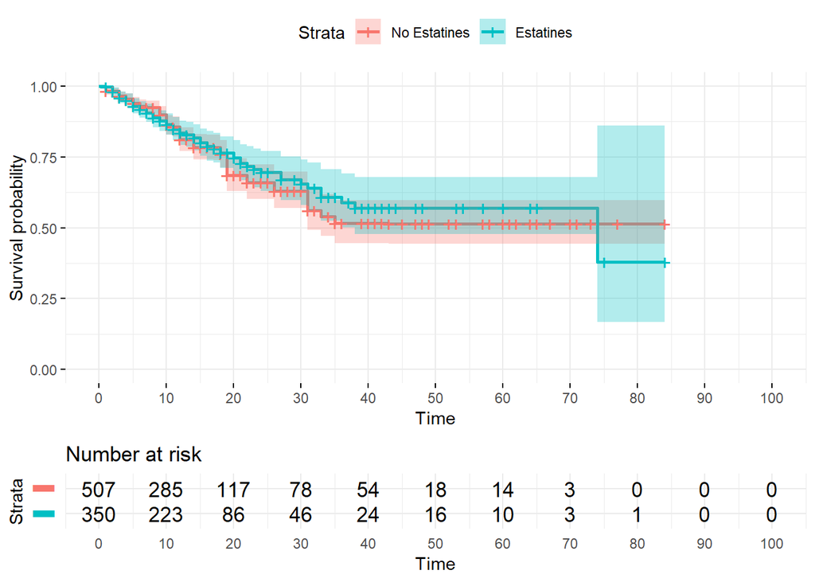

## Cox “normal”

```
## Call:
## coxph(formula = Surv(as.numeric(temps), Mort) ~ . - weights,
##     data = dfc[, c(1:43, 59, 65, 66)], weights = weights)
##
##   n= 895, number of events= 145
##
##                          coef  exp(coef)   se(coef)      z Pr(>|z|)
## Edat                9.832e-02  1.103e+00  1.149e-02  8.555  < 2e-16 ***
## TabacExfumador     -3.234e-01  7.237e-01  2.088e-01 -1.549 0.121400
## TabacSí            -8.178e-01  4.414e-01  4.270e-01 -1.915 0.055457 .
## HTASí               6.752e-01  1.964e+00  2.940e-01  2.296 0.021653 *
## HiperlipemiaSí      4.016e-01  1.494e+00  3.254e-01  1.234 0.217049
## DiabetesSí         -1.115e-01  8.945e-01  2.953e-01 -0.377 0.705814
## ObesitatSí         -1.528e-01  8.583e-01  2.076e-01 -0.736 0.461740
## Ant.CISí           -2.909e-01  7.476e-01  2.527e-01 -1.151 0.249818
## Ant.IctusSí        -2.047e-01  8.149e-01  3.163e-01 -0.647 0.517611
## Ant.MVPSí           8.576e-01  2.357e+00  2.585e-01  3.317 0.000909 ***
## Ant.Ins.CardSí      7.158e-01  2.046e+00  2.642e-01  2.709 0.006742 **
## Ant.MPOC.AsmaSí     2.472e-01  1.280e+00  2.257e-01  1.095 0.273358
## Ant.MHepCSí         3.300e-01  1.391e+00  5.214e-01  0.633 0.526796
## Ant.MRCSí           1.360e-01  1.146e+00  2.616e-01  0.520 0.603149
## Ant.MReuSí         -1.264e+00  2.824e-01  4.613e-01 -2.741 0.006120 **
## CàncerSí            7.990e-01  2.223e+00  2.234e-01  3.576 0.000349 ***
## EstatinesSí        -3.822e-01  6.824e-01  2.017e-01 -1.895 0.058124 .
## EzetimibaSí         9.361e-01  2.550e+00  3.528e-01  2.653 0.007971 **
## FibratSí            1.307e+00  3.694e+00  3.696e-01  3.536 0.000406 ***
## IECASí             -6.249e-01  5.353e-01  2.197e-01 -2.845 0.004448 **
## ARA2Sí             -7.849e-01  4.562e-01  2.818e-01 -2.785 0.005353 **
## InsulinaSí          8.831e-01  2.418e+00  3.133e-01  2.819 0.004821 **
## ISGLT2Sí           -1.381e+00  2.513e-01  6.410e-01 -2.154 0.031206 *
## GLP1Sí             -5.389e-01  5.834e-01  4.715e-01 -1.143 0.252998
## Altres.trac..DMSí   9.967e-02  1.105e+00  2.741e-01  0.364 0.716198
## A.A.NACOs          -4.052e-01  6.668e-01  3.803e-01 -1.066 0.286607
## A.A.No              1.887e-01  1.208e+00  2.546e-01  0.741 0.458483
## A.A.Sintrom        -2.078e-01  8.123e-01  2.956e-01 -0.703 0.481958
## CT..abans.ingrès    7.417e-02  1.077e+00  2.256e-01  0.329 0.742283
## HDL..abans.ingrès  -2.869e-01  7.506e-01  4.464e-01 -0.643 0.520470
## LDL..abans.ingrès  -1.578e-01  8.540e-01  2.587e-01 -0.610 0.541873
## TG.abans.ingrès     8.030e-02  1.084e+00  7.132e-02  1.126 0.260215
## FebreSí             1.085e+00  2.958e+00  3.449e-01  3.145 0.001663 **
```

[output cut: 56 more lines]

```
## Limfos.totals         1.0001     0.9999   0.99977    1.0004
## Ferritina             1.0001     0.9999   0.99997    1.0003
## PCR                   1.0026     0.9974   1.00083    1.0043
## Dímer.D               1.0000     1.0000   1.00000    1.0001
## Ins.RespSí            0.8552     1.1693   0.52031    1.4056
## Sa.O2                 0.9809     1.0194   0.96312    0.9991
## PaO2..mmHg.           0.9946     1.0054   0.98213    1.0073
## FIO2..decimals.       0.6509     1.5364   0.15300    2.7688
## PaFi                  0.9936     1.0065   0.98911    0.9981
##
## Concordance= 0.856  (se = 0.022 )
## Rsquare= 0.322   (max possible= 0.925 )
## Likelihood ratio test= 347.3  on 47 df,   p=<2e-16
## Wald test            = 283.4  on 47 df,   p=<2e-16
## Score (logrank) test = 356.3  on 47 df,   p=<2e-16
```

Forest plot:

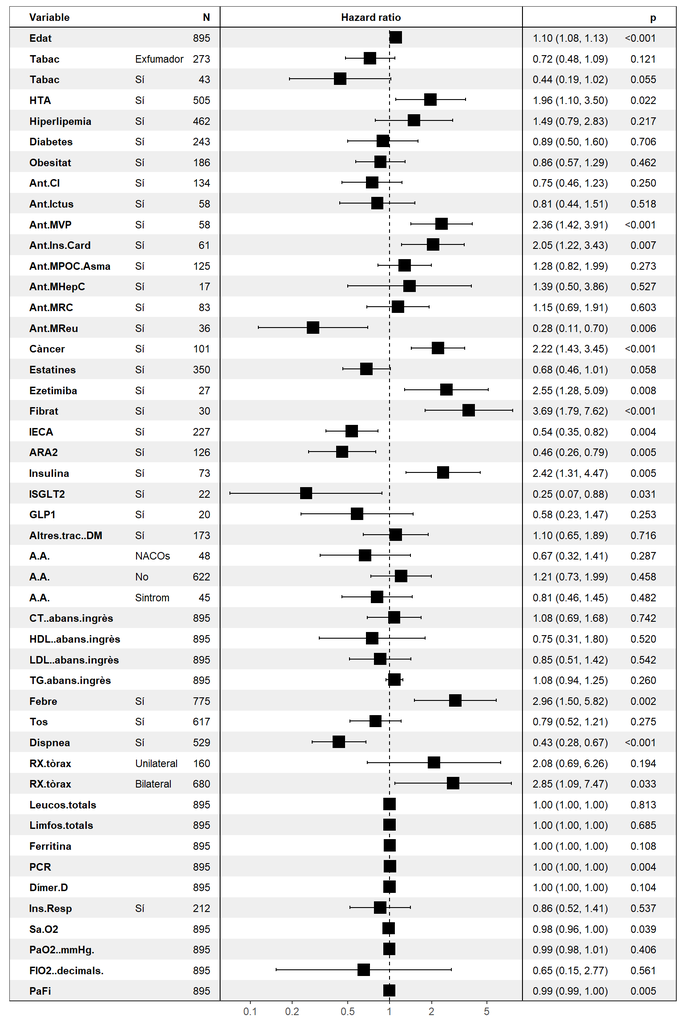

Aquí he de treure els que estan 0 dies:

# Competing risks

Ara comparem tant la probabilitat de morir com la probabilitat d’alta en un model de competing risks:

Finegray analysis (competitive risk):

Mortalitat:

```
## Call:
## coxph(formula = Surv(fgstart, fgstop, fgstatus) ~ . - Mort -
##     fgwt - weights, data = fg, weights = weights)
##
##   n= 895, number of events= 145
##
##                          coef  exp(coef)   se(coef)      z Pr(>|z|)
## Edat                9.749e-02  1.102e+00  1.146e-02  8.507  < 2e-16 ***
## TabacExfumador     -3.208e-01  7.256e-01  2.093e-01 -1.533 0.125394
## TabacSí            -8.169e-01  4.418e-01  4.267e-01 -1.914 0.055568 .
## HTASí               6.444e-01  1.905e+00  2.931e-01  2.199 0.027880 *
## HiperlipemiaSí      4.031e-01  1.496e+00  3.254e-01  1.239 0.215427
## DiabetesSí         -1.099e-01  8.959e-01  2.947e-01 -0.373 0.709178
## ObesitatSí         -1.460e-01  8.641e-01  2.076e-01 -0.703 0.481825
## Ant.CISí           -2.730e-01  7.611e-01  2.528e-01 -1.080 0.280200
## Ant.IctusSí        -2.141e-01  8.073e-01  3.163e-01 -0.677 0.498499
## Ant.MVPSí           8.804e-01  2.412e+00  2.578e-01  3.415 0.000638 ***
## Ant.Ins.CardSí      7.072e-01  2.028e+00  2.638e-01  2.681 0.007344 **
## Ant.MPOC.AsmaSí     2.568e-01  1.293e+00  2.255e-01  1.139 0.254691
## Ant.MHepCSí         2.930e-01  1.340e+00  5.221e-01  0.561 0.574669
## Ant.MRCSí           1.401e-01  1.150e+00  2.635e-01  0.532 0.594925
## Ant.MReuSí         -1.258e+00  2.843e-01  4.620e-01 -2.722 0.006487 **
## CàncerSí            7.992e-01  2.224e+00  2.235e-01  3.575 0.000350 ***
## EstatinesSí        -3.902e-01  6.769e-01  2.024e-01 -1.927 0.053934 .
## EzetimibaSí         9.258e-01  2.524e+00  3.523e-01  2.628 0.008587 **
## FibratSí            1.321e+00  3.747e+00  3.694e-01  3.576 0.000349 ***
## IECASí             -6.374e-01  5.287e-01  2.204e-01 -2.891 0.003835 **
## ARA2Sí             -7.963e-01  4.510e-01  2.829e-01 -2.815 0.004879 **
## InsulinaSí          8.934e-01  2.443e+00  3.122e-01  2.862 0.004214 **
## ISGLT2Sí           -1.399e+00  2.468e-01  6.403e-01 -2.185 0.028890 *
## GLP1Sí             -5.095e-01  6.008e-01  4.710e-01 -1.082 0.279373
## Altres.trac..DMSí   8.103e-02  1.084e+00  2.733e-01  0.296 0.766886
## A.A.NACOs          -3.936e-01  6.746e-01  3.804e-01 -1.035 0.300870
## A.A.No              1.906e-01  1.210e+00  2.556e-01  0.746 0.455840
## A.A.Sintrom        -1.858e-01  8.304e-01  2.963e-01 -0.627 0.530526
## CT..abans.ingrès    6.566e-02  1.068e+00  2.265e-01  0.290 0.771950
## HDL..abans.ingrès  -2.664e-01  7.661e-01  4.474e-01 -0.596 0.551477
## LDL..abans.ingrès  -1.546e-01  8.567e-01  2.596e-01 -0.596 0.551437
## TG.abans.ingrès     8.363e-02  1.087e+00  7.114e-02  1.176 0.239744
## FebreSí             1.052e+00  2.864e+00  3.447e-01  3.053 0.002265 **
```

[output cut: 56 more lines]

```
## Limfos.totals         1.0001     0.9999   0.99977    1.0003
## Ferritina             1.0001     0.9999   0.99997    1.0003
## PCR                   1.0026     0.9974   1.00089    1.0044
## Dímer.D               1.0000     1.0000   1.00000    1.0001
## Ins.RespSí            0.8567     1.1673   0.52149    1.4074
## Sa.O2                 0.9811     1.0192   0.96336    0.9993
## PaO2..mmHg.           0.9943     1.0057   0.98182    1.0070
## FIO2..decimals.       0.6862     1.4572   0.16114    2.9224
## PaFi                  0.9939     1.0061   0.98945    0.9984
##
## Concordance= 0.855  (se = 0.022 )
## Rsquare= 0.321   (max possible= 0.925 )
## Likelihood ratio test= 346.8  on 47 df,   p=<2e-16
## Wald test            = 284.1  on 47 df,   p=<2e-16
## Score (logrank) test = 356.8  on 47 df,   p=<2e-16
```

Molt bon resultat!

Mirem les altes:

```
## Call:
## coxph(formula = Surv(fgstart, fgstop, fgstatus) ~ . - Mort -
##     crvar - fgwt - weights, data = fg, weights = weights)
##
##   n= 895, number of events= 728
##
##                          coef  exp(coef)   se(coef)      z Pr(>|z|)
## Edat               -8.715e-03  9.913e-01  4.657e-03 -1.871 0.061287 .
## TabacExfumador      2.801e-01  1.323e+00  1.066e-01  2.627 0.008607 **
## TabacSí            -3.192e-01  7.268e-01  1.809e-01 -1.764 0.077747 .
## HTASí              -1.585e-01  8.535e-01  1.398e-01 -1.133 0.257008
## HiperlipemiaSí      2.273e-01  1.255e+00  1.609e-01  1.412 0.157807
## DiabetesSí          1.221e-02  1.012e+00  1.391e-01  0.088 0.930077
## ObesitatSí          1.926e-02  1.019e+00  1.073e-01  0.180 0.857520
## Ant.CISí            1.835e-01  1.201e+00  1.263e-01  1.453 0.146210
## Ant.IctusSí        -2.140e-01  8.073e-01  1.615e-01 -1.325 0.185015
## Ant.MVPSí          -8.544e-01  4.255e-01  2.033e-01 -4.203 2.63e-05 ***
## Ant.Ins.CardSí      2.513e-01  1.286e+00  1.673e-01  1.502 0.133025
## Ant.MPOC.AsmaSí    -1.842e-01  8.317e-01  1.318e-01 -1.398 0.162252
## Ant.MHepCSí         3.408e-01  1.406e+00  2.829e-01  1.204 0.228403
## Ant.MRCSí           5.559e-01  1.744e+00  1.554e-01  3.576 0.000348 ***
## Ant.MReuSí          5.575e-01  1.746e+00  1.824e-01  3.057 0.002236 **
## CàncerSí            4.138e-01  1.513e+00  1.319e-01  3.138 0.001700 **
## EstatinesSí        -2.565e-01  7.737e-01  1.050e-01 -2.443 0.014568 *
## EzetimibaSí         3.448e-01  1.412e+00  2.225e-01  1.550 0.121177
## FibratSí            3.695e-01  1.447e+00  2.007e-01  1.841 0.065666 .
## IECASí              2.077e-03  1.002e+00  1.270e-01  0.016 0.986947
## ARA2Sí              5.403e-01  1.717e+00  1.398e-01  3.864 0.000111 ***
## InsulinaSí         -7.309e-01  4.815e-01  1.798e-01 -4.064 4.82e-05 ***
## ISGLT2Sí            4.949e-01  1.640e+00  2.434e-01  2.033 0.042071 *
## GLP1Sí              4.771e-01  1.611e+00  3.156e-01  1.512 0.130581
## Altres.trac..DMSí  -4.384e-01  6.451e-01  1.483e-01 -2.955 0.003125 **
## A.A.NACOs          -4.131e-01  6.616e-01  2.009e-01 -2.056 0.039743 *
## A.A.No             -7.561e-02  9.272e-01  1.251e-01 -0.604 0.545586
## A.A.Sintrom         1.385e-01  1.149e+00  1.785e-01  0.776 0.437634
## CT..abans.ingrès   -1.923e-02  9.810e-01  6.646e-02 -0.289 0.772340
## HDL..abans.ingrès   5.354e-01  1.708e+00  1.834e-01  2.919 0.003510 **
## LDL..abans.ingrès  -1.140e-01  8.922e-01  9.079e-02 -1.256 0.209177
## TG.abans.ingrès     5.144e-02  1.053e+00  3.082e-02  1.669 0.095168 .
## FebreSí            -4.571e-01  6.331e-01  1.383e-01 -3.305 0.000949 ***
```

[output cut: 56 more lines]

```
## Limfos.totals         1.0001     0.9999    0.9999    1.0003
## Ferritina             0.9997     1.0003    0.9997    0.9998
## PCR                   0.9980     1.0020    0.9968    0.9993
## Dímer.D               0.9999     1.0001    0.9999    1.0000
## Ins.RespSí            1.1101     0.9008    0.8588    1.4349
## Sa.O2                 1.0229     0.9776    1.0076    1.0384
## PaO2..mmHg.           0.9867     1.0135    0.9797    0.9937
## FIO2..decimals.       2.4296     0.4116    0.9335    6.3237
## PaFi                  1.0078     0.9923    1.0054    1.0102
##
## Concordance= 0.802  (se = 0.015 )
## Rsquare= 0.478   (max possible= 1 )
## Likelihood ratio test= 581  on 47 df,   p=<2e-16
## Wald test            = 487.8  on 47 df,   p=<2e-16
## Score (logrank) test = 564.9  on 47 df,   p=<2e-16
```

Dibuixem les corbes:

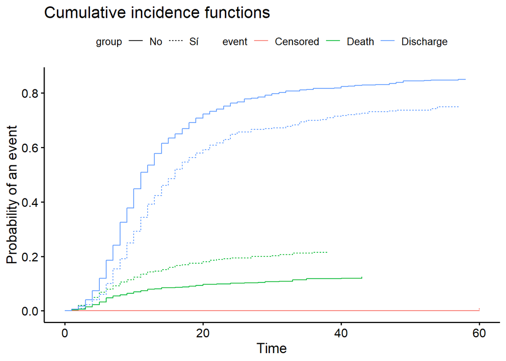

Més gràfics:

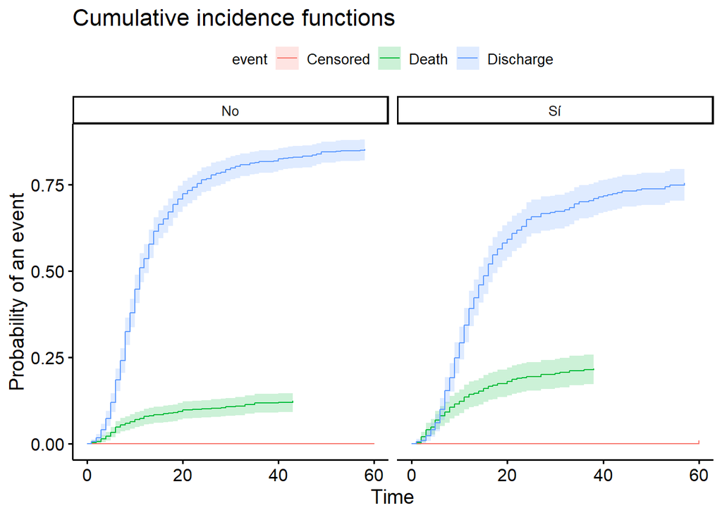